Coding Essentials for Astronomers

# SciPy: Random Variable and Measurement Uncertainty

## Introduction

In Lecture 16, you learned to work with discrete astronomical data using interpolation, differentiation, and integration. These techniques assumed you knew the exact values at your data points - the calculations were **deterministic**, meaning given the same inputs, you always get exactly the same outputs.

But real astronomical observations are never perfectly precise. When you measure a star's brightness, you don't get a single exact number - you get a value with uncertainty. Point your telescope at the same star twice under identical conditions, and you'll get slightly different measurements. This uncertainty isn't a failure of your technique - it's a fundamental feature of working with real data.

Imagine you observe a star on ten different nights and measure its magnitude as: 11.85, 11.92, 11.78, 11.90, 11.74, 11.87, 11.95, 11.80, 11.88, 11.99. These measurements scatter around some central value, but which single number best represents the star's true magnitude? How confident should you be in that estimate? Should you trust all ten measurements equally, or are some more reliable than others? What if one measurement (say, 13.5) looks suspicious - how do you decide if it's a real fluctuation or just a bad measurement?

In this lecture, you'll learn to analyze real astronomical data with proper statistical rigor. By the end, you'll be able to combine noisy measurements properly, detect and remove bad data, quantify your uncertainties, and validate your statistical assumptions - skills essential for Lecture 18, where you'll fit models to data.

Let's import the libraries we'll use throughout this lecture:

```python
# Import libraries for numerical computing, plotting, and statistics
import numpy as np
import matplotlib.pyplot as plt
from scipy import stats

# Configure default plot settings
plt.rcParams['figure.figsize'] = (12, 8)
plt.rcParams['font.size'] = 12
```

## From Random Numbers to Patterns

In the NumPy lecture, you learned about `np.random.normal()` and saw how to generate random numbers and visualize them with histograms. Let's quickly revisit that concept.

We'll use `np.random.normal()` with three key parameters: `loc` (the center or mean of the distribution), `scale` (the width or standard deviation of the distribution), and `size` (how many random numbers to generate).

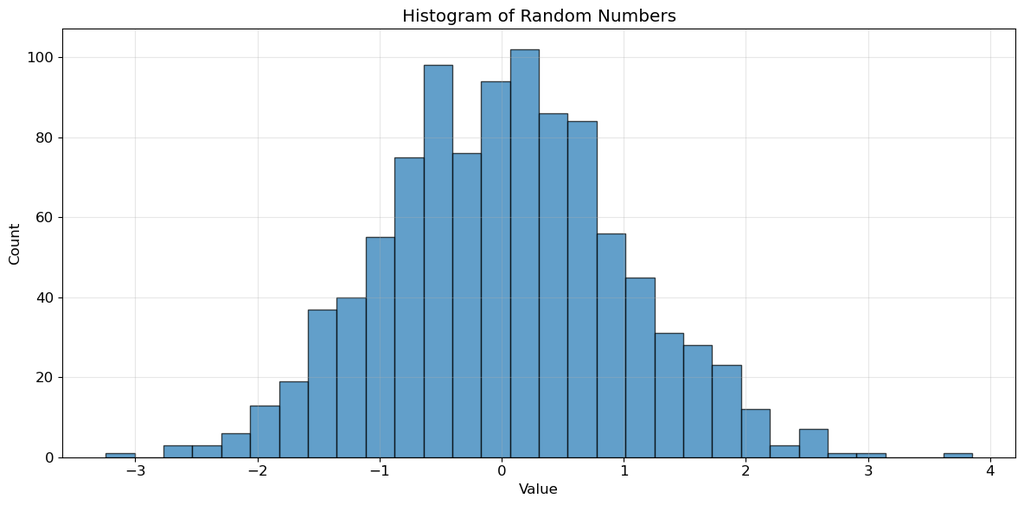

```python
# Set random seed for reproducibility
np.random.seed(42)

# Generate 1000 random numbers from a Gaussian distribution
# loc=0 sets the center (mean), scale=1 sets the width (standard deviation)
data = np.random.normal(loc=0, scale=1, size=1000)

# Create histogram to visualize the distribution
plt.figure(figsize=(12, 6))
plt.hist(data, bins=30, edgecolor='black', alpha=0.7)
plt.xlabel('Value')
plt.ylabel('Count')
plt.title('Histogram of Random Numbers')
plt.grid(True, alpha=0.3)
plt.tight_layout()
plt.show()
```

You saw that the histogram forms a bell-shaped pattern. In the NumPy lecture, this was a programming tool - a way to add randomness to simulations. But now we need to ask a deeper question: **what does this pattern actually mean mathematically?**

Understanding and quantifying this uncertainty requires **statistics** - the mathematics of randomness and uncertainty. **SciPy's statistics module** (`scipy.stats`) provides the tools for this analysis. While NumPy gives us basic functions like `np.mean()` and `np.std()`, SciPy provides the full machinery: probability distributions, hypothesis tests, and statistical analysis methods.

## Random Variables: Deterministic vs Random

Before we can model the pattern in our histogram, we need to understand what we're modeling. The key distinction is between quantities that are **deterministic** versus those that are **random**.

A **deterministic variable** always yields the same value given the same conditions. Consider Kepler's Third Law for planetary orbits:

$$P^2 = \frac{4\pi^2}{GM}a^3$$

Given a planet's semi-major axis $a$ and the Sun's mass $M$, the orbital period $P$ is completely determined. Every time you compute it with the same values of $a$ and $M$, you get exactly the same answer. There's no randomness, no variation, no uncertainty in the calculation itself.

A **random variable**, in contrast, is one whose value varies unpredictably. Even when all known conditions are specified, we can only predict probabilities of different outcomes, not the exact outcome itself. When you measure a star's magnitude, that measurement is a random variable. The star's true magnitude is fixed and deterministic, but your measurement includes random noise from many sources: the atmosphere is turbulent and constantly changing how much light reaches your detector, your detector electronics have random variations in sensitivity, background light from the sky adds random contributions, and if you're unlucky, passing satellites or other objects might contaminate your measurement. Each time you measure, these random effects combine differently, giving you a different result.

This is where **statistics** enters. Statistics is the art and science of quantifying random variables. It provides the tools to describe randomness mathematically, to extract information from noisy data, to distinguish real signals from random fluctuations, and to quantify our uncertainty about what we've measured. When we say a star has magnitude 10.5 ± 0.1, that ±0.1 comes from statistical analysis. When we claim two stars have significantly different brightnesses, we use statistics to determine if the difference is real or just noise. When we combine measurements from multiple nights, statistics tells us how to weight them properly.

Even though the star's true magnitude is deterministic, our **knowledge** of that magnitude is uncertain. We represent this uncertain knowledge using random variables and probability distributions. A random variable isn't just about physical randomness - it's about modeling our uncertainty given incomplete information and noisy measurements.

## Probability Distributions: Describing Random Variables

How do we mathematically describe a random variable? We use a **probability distribution**.

A probability distribution is a complete mathematical description of a random variable. It tells us everything we need to know about the variable's behavior: which values are possible, which values are more likely, and which are less likely. Think of it as a mathematical recipe that fully characterizes the randomness.

Look back at the histogram you created earlier. Notice how some values appear more frequently than others? The values near zero occur most often, while values far from zero are rare. This pattern isn't random - it's systematic and predictable. A probability distribution is the smooth, mathematical version of this pattern. While your histogram depends on arbitrary choices (how many bins? what bin width?), the probability distribution is the underlying mathematical truth that the histogram is trying to approximate.

Once you know the probability distribution, you can answer any question about the random variable. What's the probability of getting a value between 0 and 1? What's the most likely value? What's the average value you'd expect? How spread out are the values? The probability distribution contains all this information in a compact mathematical form.

For continuous measurements like stellar magnitudes, we describe the distribution using a **probability density function** (PDF), denoted $p(x)$. The PDF is a function that tells us the relative likelihood of different values. Think of it as a smooth curve that captures the bell-shaped pattern we saw in the histogram. The PDF must satisfy two fundamental requirements:

$$p(x) \geq 0 \text{ for all } x$$

This says probability density is never negative. You can't have negative probability.

$$\int_{-\infty}^{\infty} p(x)\,dx = 1$$

This says the total probability across all possible values equals 1, representing certainty that the variable has some value. The PDF itself is not a probability - it's a **density**. Just as mass density tells you mass per unit volume, probability density tells you probability per unit interval. To get actual probabilities, you integrate the PDF over an interval:

$$P(a \leq X \leq b) = \int_a^b p(x)\,dx$$

This integral gives the area under the PDF curve between $a$ and $b$, which equals the probability that $X$ falls in that range. Higher PDF values indicate more probable regions, but you must integrate to get actual probabilities.

Let's visualize this concept by overlaying a smooth PDF on our histogram. We'll use `plt.hist()` with the `density=True` parameter to normalize the histogram so it matches the scale of the PDF (probability per unit, rather than raw counts):

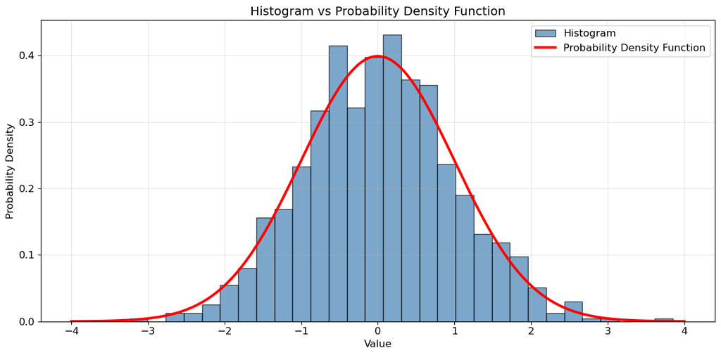

```python
# Set random seed for reproducibility
np.random.seed(42)

# Generate random data
data = np.random.normal(loc=0, scale=1, size=1000)

# Create x values for the PDF curve
x = np.linspace(-4, 4, 1000)

# Calculate the standard Gaussian PDF: (1/√(2π)) * exp(-x²/2)
pdf_values = (1 / np.sqrt(2 * np.pi)) * np.exp(-x**2 / 2)

# Plot histogram with density=True to normalize it to probability density
plt.figure(figsize=(12, 6))
plt.hist(data, bins=30, density=True, alpha=0.7, edgecolor='black',
         color='steelblue', label='Histogram')
plt.plot(x, pdf_values, 'r-', linewidth=3, label='Probability Density Function')
plt.xlabel('Value')
plt.ylabel('Probability Density')
plt.title('Histogram vs Probability Density Function')
plt.legend()
plt.grid(True, alpha=0.3)
plt.tight_layout()
plt.show()
```

The smooth red curve is the PDF - a mathematical function that models the pattern we see in the histogram. While the histogram depends on our choice of bins and is jumpy, the PDF provides a smooth, continuous description. This mathematical description is far more powerful than just looking at the histogram because it lets us make quantitative predictions and answer precise questions.

But to work with PDFs effectively, we first need to understand the basic statistical quantities that characterize them. Before we can specify that a distribution has `loc=10, scale=2`, we need to know what those parameters mean. That's where descriptive statistics come in.

## Descriptive Statistics: Quantifying Distributions

We've visualized distributions with histograms and seen that PDFs provide mathematical descriptions. But what do the numbers that characterize these distributions actually mean? Before we work with distribution functions, we need to understand the fundamental quantities that describe data: measures of center and spread.

These **descriptive statistics** are numerical summaries that characterize our data. They're not abstract mathematical concepts - they're concrete numbers you can calculate from your measurements, and they tell you essential information about your data's pattern.

### The Mean: Center of Mass

The **mean** (or average) is calculated by summing all values and dividing by the count:

$$\bar{x} = \frac{1}{n}\sum_{i=1}^n x_i$$

Think of the mean as the "center of mass" or "balance point" of your data. If you placed weights at each data point on a number line, the mean is where you'd place a fulcrum to balance them perfectly. Let's compute it:

```python
# Set random seed for reproducibility
np.random.seed(42)

# Generate 100 measurements centered at loc=10 with scale=2
data = np.random.normal(loc=10, scale=2, size=100)

# Calculate the mean using np.mean()
mean_value = np.mean(data)

print(f"Mean: {mean_value:.3f}")
```

```
Mean: 9.792
```

The mean gives us a single number representing the center of the data. For symmetric, bell-shaped data, the mean is optimal in a precise mathematical sense - it minimizes the sum of squared deviations from all data points. This makes it the natural choice for estimating the center when errors are symmetric. However, the mean has a critical weakness - it's sensitive to extreme values. A single outlier can pull the mean far from the bulk of the data.

### The Median: The Middle Value

The **median** is the middle value when all measurements are sorted in order. Half the data falls below the median, half above. For our 100 measurements, the median is the average of the 50th and 51st values when sorted.

**Important note:** When the dataset has an even number of values (like our 100 measurements), both NumPy and SciPy calculate the median by taking the average of the two middle values. Similarly, for quartiles (Q1 and Q3), if the split point falls between two values, they use linear interpolation to compute the quartile value:

```python
# Calculate the median using np.median()
median_value = np.median(data)

print(f"Mean: {mean_value:.3f}")
print(f"Median: {median_value:.3f}")
```

```
Mean: 9.792
Median: 9.746
```

For symmetric distributions, the mean and median are approximately equal (both at the center of symmetry). But the median has a powerful advantage: it's **robust** to outliers. You can change the most extreme values as much as you want, and as long as they stay extreme, the median won't move. This makes the median ideal when you suspect outliers or when your distribution is skewed rather than symmetric.

### The Standard Deviation: Measuring Spread

Knowing the center isn't enough - we also need to quantify the **spread** or **dispersion** of the data. How scattered are the measurements? The **standard deviation** quantifies typical deviations from the mean:

$$s = \sqrt{\frac{1}{n}\sum_{i=1}^n (x_i - \bar{x})^2}$$

**Note:** The standard deviation is also commonly known as the **root mean square (RMS)** deviation because of its formula structure - you compute the squared deviations, take their mean, then take the square root. This terminology is frequently used in engineering and physics contexts.

Let's break this down step by step. First, we compute how far each measurement deviates from the mean: $(x_i - \bar{x})$. These deviations can be positive or negative. We square these deviations for two reasons: so positive and negative deviations don't cancel out, and to penalize large deviations more heavily than small ones. We sum all squared deviations and divide by $n$ to get the average squared deviation. Finally, we take the square root to return to original units:

```python
# Calculate the standard deviation using np.std()
std_value = np.std(data)

print(f"Standard deviation: {std_value:.3f}")
```

```
Standard deviation: 1.807
```

The standard deviation tells us the typical size of deviations from the mean. If your data follows a bell-shaped pattern, about 68% of values fall within one standard deviation of the mean, about 95% within two standard deviations, and about 99.7% within three standard deviations. This is why the standard deviation is so fundamental - it directly quantifies uncertainty in a precise, predictable way.

The **variance** is simply the square of the standard deviation: $s^2 = \sigma^2$. We can calculate it using `np.var()`:

```python
# Calculate the variance using np.var()
var_value = np.var(data)

print(f"Variance: {var_value:.3f}")
print(f"Standard deviation: {std_value:.3f}")
print(f"Relationship: variance = std² = {std_value**2:.3f}")
```

```
Variance: 3.266
Standard deviation: 1.807
Relationship: variance = std² = 3.266
```

While less intuitive than standard deviation (it's in squared units), variance has important mathematical properties. When combining independent random variables, variances add. This makes variance the natural quantity for mathematical calculations, even though we usually report standard deviations because they're in the same units as our measurements.

### The Interquartile Range: Robust Spread

The mean and standard deviation are excellent for symmetric, bell-shaped data without outliers. But what if your data contains a few bad measurements? The standard deviation will be inflated by outliers, giving a misleadingly large estimate of typical spread. When your data includes outliers, you need **robust statistics** - measures that resist the influence of extreme values.

The **interquartile range** (IQR) is a robust alternative to standard deviation. Quartiles divide the data into quarters: Q1 (25th percentile), Q2 (50th percentile = median), and Q3 (75th percentile). The IQR is the width of the middle 50%:

$$\text{IQR} = Q_3 - Q_1$$

Unlike standard deviation, the IQR is completely unaffected by extreme values in the tails. Let's compute it using `np.percentile()` which takes two arguments: the data array and the percentile value (e.g., `25` for the 25th percentile, `75` for the 75th percentile). Alternatively, `stats.iqr()` from SciPy calculates the IQR directly in one step:

```python
# Calculate the 25th percentile (Q1) using np.percentile()
q1 = np.percentile(data, 25)

# Calculate the 75th percentile (Q3) using np.percentile()
q3 = np.percentile(data, 75)

# Calculate IQR as the difference between Q3 and Q1
iqr = q3 - q1

# Alternatively, use stats.iqr() which does this calculation directly
iqr_scipy = stats.iqr(data)

print(f"Q1 (25th percentile): {q1:.3f}")
print(f"Q3 (75th percentile): {q3:.3f}")
print(f"IQR = Q3 - Q1: {iqr:.3f}")
print(f"Using stats.iqr(): {iqr_scipy:.3f}")
```

```
Q1 (25th percentile): 8.798
Q3 (75th percentile): 10.812
IQR = Q3 - Q1: 2.014
Using stats.iqr(): 2.014
```

For bell-shaped data without outliers, there's a predictable relationship: IQR ≈ 1.35×(standard deviation). But when outliers are present, the IQR remains stable while the standard deviation explodes.

Now that we understand what mean, standard deviation, median, and IQR actually measure, we can properly interpret distribution parameters. When we see a distribution specified as "mean=10, std=2", we now know exactly what those numbers mean and how they relate to the data.

## The Gaussian Distribution

We've been looking at bell-shaped patterns, and there's a specific mathematical function that describes this shape: the **Gaussian distribution**. This distribution is also commonly known as the **normal distribution** - both names refer to the same mathematical function, and you'll see both terms used interchangeably in statistics and scientific literature. Measurement errors in astronomy are very often Gaussian-distributed. When you measure stellar brightnesses, positions, velocities, or any other quantity, the errors typically follow this bell-curve shape.

The Gaussian distribution is characterized by two parameters that you now understand: the **mean** (denoted μ, pronounced "mu") which specifies the center of the distribution, and the **standard deviation** (denoted σ, pronounced "sigma") which specifies the width or spread. The probability density function is:

$$p(x) = \frac{1}{\sigma\sqrt{2\pi}} \exp\left(-\frac{(x-\mu)^2}{2\sigma^2}\right)$$

You don't need to memorize this formula - scipy.stats will handle it for you. But notice how μ and σ appear: μ shifts the peak of the bell curve left or right, while σ controls how wide or narrow the bell curve is. Larger σ means more spread-out data, smaller σ means tightly concentrated data.

Why is the Gaussian distribution so ubiquitous? The answer comes from a profound mathematical theorem called the **Central Limit Theorem**. While the full mathematical statement is sophisticated, the intuitive idea is remarkably simple: when many small, independent random effects add together, the result approaches a Gaussian distribution - regardless of what distributions those individual effects follow.

Consider measuring a star's brightness with a telescope and camera. Many small random effects contribute to measurement error. Light from the star passes through Earth's atmosphere, which is constantly moving and turbulent - sometimes the atmosphere is steady and transparent, sometimes it's wavy and absorbs more light. Your camera's detector (called a CCD, or charge-coupled device - essentially a digital camera chip optimized for astronomy) has tiny random variations in how it responds to light at different locations and times. Electronic circuits that read out the data add small random noise. Background light from the sky, other stars, or even satellites can randomly contribute. None of these individual effects necessarily follows a bell curve, but when they all add together, the Central Limit Theorem guarantees the total error is approximately Gaussian. This isn't an assumption - it's a mathematical inevitability when many independent random effects combine.

You can also think about human height as an example. Height is determined by many genetic and environmental factors - nutrition during childhood, hundreds of genes each contributing small amounts, hormones, health conditions, and so on. Each factor has its own distribution of effects. But when you measure the heights of many people, the distribution is bell-shaped and approximately Gaussian. This same pattern appears whenever many independent effects combine.

Let's see this convergence in action. We'll generate data from a completely non-Gaussian distribution (uniform) and watch how summing multiple such random variables produces a Gaussian shape:

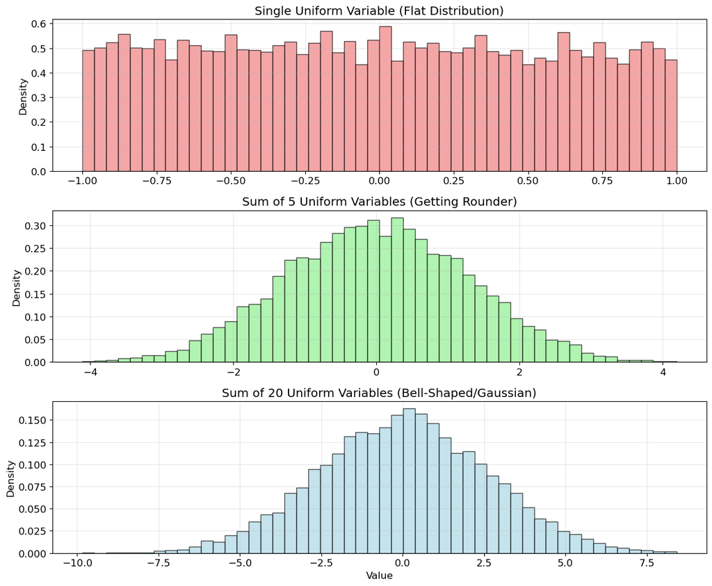

```python
# Set random seed for reproducibility
np.random.seed(42)

n_samples = 10000

# Generate random data
uniform_data = np.random.uniform(-1, 1, n_samples)

# Create array for computation
sum_of_5 = np.zeros(n_samples)

# Sum multiple random variables (Central Limit Theorem)
for i in range(5):
    # Generate random data
    sum_of_5 += np.random.uniform(-1, 1, n_samples)

# Create array for computation
sum_of_20 = np.zeros(n_samples)
# Sum multiple random variables (Central Limit Theorem)
for i in range(20):
    # Generate random data
    sum_of_20 += np.random.uniform(-1, 1, n_samples)

# Create and configure plot
plt.figure(figsize=(12, 10))

plt.subplot(3, 1, 1)
plt.hist(uniform_data, bins=50, density=True, alpha=0.7, edgecolor='black', color='lightcoral')
plt.title('Single Uniform Variable (Flat Distribution)')
plt.ylabel('Density')
plt.grid(True, alpha=0.3)

plt.subplot(3, 1, 2)
plt.hist(sum_of_5, bins=50, density=True, alpha=0.7, edgecolor='black', color='lightgreen')
plt.title('Sum of 5 Uniform Variables (Getting Rounder)')
plt.ylabel('Density')
plt.grid(True, alpha=0.3)

plt.subplot(3, 1, 3)
plt.hist(sum_of_20, bins=50, density=True, alpha=0.7, edgecolor='black', color='lightblue')
plt.title('Sum of 20 Uniform Variables (Bell-Shaped/Gaussian)')
plt.xlabel('Value')
plt.ylabel('Density')
plt.grid(True, alpha=0.3)

plt.tight_layout()
plt.show()
```

The top panel shows a single uniform random variable - completely flat, nowhere near Gaussian. The middle panel shows the sum of 5 uniform variables - already developing a rounded peak. The bottom panel shows the sum of 20 uniform variables - unmistakably bell-shaped and essentially Gaussian. This is the Central Limit Theorem in action: sum enough independent random effects, and you get a Gaussian, regardless of what the individual effects look like.

This explains why Gaussian distributions dominate observational astronomy. Every measurement involves countless independent random processes, and their sum produces Gaussian-distributed errors. Understanding the Gaussian distribution is therefore essential for analyzing real data.

## Working with Distributions Using scipy.stats

Now that we understand what probability distributions are and what their parameters (like μ and σ for Gaussians) mean, we're ready to work with them computationally. NumPy can generate random numbers from various distributions using `np.random`, but SciPy's `scipy.stats` module provides much more control and functionality. Instead of just generating random numbers, scipy.stats gives you complete access to the mathematical properties of distributions: computing probability densities, cumulative probabilities, percentiles, moments, and much more.

The power of scipy.stats comes from **distribution objects**. Rather than calling different functions for different tasks, you create a single distribution object that encapsulates all the properties of that distribution. Then you can ask that object to do various calculations. This provides a clean, consistent interface that works the same way for all distributions.

Let's see how this works with the Gaussian distribution. The function `stats.norm()` creates a Gaussian distribution object. You specify the distribution's parameters when you create it. For a Gaussian, you specify `loc` (the mean μ) and `scale` (the standard deviation σ):

```python
# Create a Gaussian distribution object with loc=0 (mean) and scale=1 (std dev)
gaussian = stats.norm(loc=0, scale=1)
```

This creates a distribution object representing the standard Gaussian: centered at 0 with width 1. The parameters `loc` and `scale` are generic names that work across all distributions in `scipy.stats`. For Gaussians, `loc=μ` (the mean) and `scale=σ` (the standard deviation). Now we can use this object to perform various calculations.

### Computing the PDF

The `.pdf()` method computes the probability density at any value. Instead of manually typing the Gaussian formula, we just call `.pdf()`. Let's start with a single value:

```python
# Define a single x value where we want to evaluate the PDF
x_single = 0.0

# Use the .pdf() method to compute probability density at x_single
density = gaussian.pdf(x_single)

print(f"Probability density at x={x_single}: {density:.4f}")
```

```
Probability density at x=0.0: 0.3989
```

Here `x_single=0.0` is the location where we want to know the probability density. The method `.pdf()` returns that density value. For the standard Gaussian centered at 0, the density is highest at `x=0` (the peak of the bell curve) and decreases as you move away from the center.

Now let's compute the PDF at many points so we can plot the entire curve:

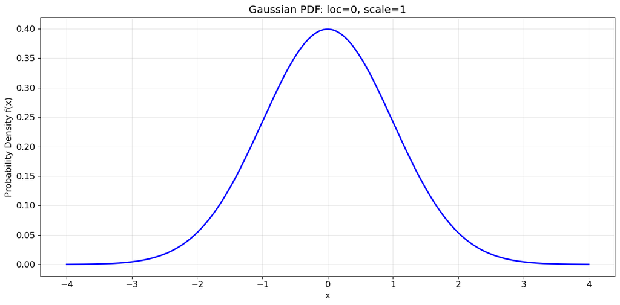

```python
# Create an array of x values from -4 to 4
x_array = np.linspace(-4, 4, 1000)

# Use the .pdf() method to compute probability density at each x value
pdf_array = gaussian.pdf(x_array)

# Plot the PDF curve
plt.figure(figsize=(12, 6))
plt.plot(x_array, pdf_array, 'b-', linewidth=2)
plt.xlabel('x')
plt.ylabel('Probability Density f(x)')
plt.title('Gaussian PDF: loc=0, scale=1')
plt.grid(True, alpha=0.3)
plt.tight_layout()
plt.show()
```

This creates the familiar bell curve. The `.pdf()` method works the same way whether you give it a single number or an array - it computes the probability density at each point. Notice we didn't have to write any formulas ourselves. SciPy handles all the mathematics internally. This is the power of the distribution object approach - the same simple interface gives you access to complex mathematical functions.

### Generating Random Samples

The `.rvs()` method (short for "random variates") draws random samples from the distribution. **Note:** The term "random variates" refers to random values drawn from a specific probability distribution - they are realizations or samples from that distribution. This connects to `np.random.normal()` that you learned in the NumPy lecture, but it's part of the unified `scipy.stats` interface. The parameter `size` tells it how many random numbers to generate:

```python
# Set random seed for reproducibility
np.random.seed(42)

# Use the .rvs() method to generate 5 random samples from the distribution
samples = gaussian.rvs(size=5)

print(f"Five random samples: {samples}")
```

```
Five random samples: [ 0.49671415 -0.1382643   0.64768854  1.52302986 -0.23415337]
```

This generates 5 random numbers drawn from our Gaussian distribution. Each time you call `.rvs()`, you get different random values (unless you set a random seed with `np.random.seed()`). These samples are useful for simulating measurements, testing analysis pipelines with synthetic data, and propagating uncertainties through calculations.

Let's generate many samples (using `size=10000`) and verify they match the theoretical PDF. When we plot the histogram, we'll use `bins=50` to divide the data into 50 bins, `density=True` to normalize the histogram to match the PDF scale.

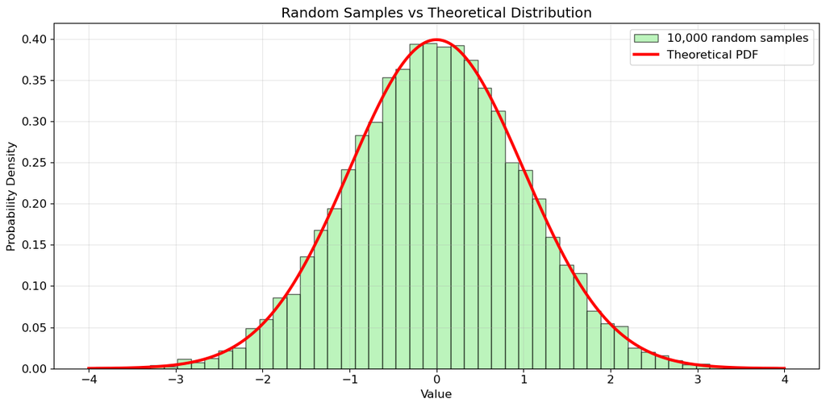

```python
# Generate 10,000 random samples using .rvs()
many_samples = gaussian.rvs(size=10000)

# Create x values for plotting the theoretical PDF
x = np.linspace(-4, 4, 1000)

# Calculate the theoretical PDF
pdf = gaussian.pdf(x)

# Plot histogram of samples (density=True normalizes to probability density)
plt.figure(figsize=(12, 6))
plt.hist(many_samples, bins=50, density=True, alpha=0.6, edgecolor='black',
         color='lightgreen', label='10,000 random samples')
plt.plot(x, pdf, 'r-', linewidth=3, label='Theoretical PDF')
plt.xlabel('Value')
plt.ylabel('Probability Density')
plt.title('Random Samples vs Theoretical Distribution')
plt.legend()
plt.grid(True, alpha=0.3)
plt.tight_layout()
plt.show()
```

The histogram of samples closely matches the theoretical PDF curve. With more samples, the match would become even better. This confirms that `.rvs()` is correctly drawing random numbers from the specified distribution.

### The Cumulative Distribution Function

The PDF tells us probability density at each point, but often we want to know cumulative probabilities: "What fraction of measurements fall below magnitude 10.5?" or "What value separates the brightest 10% from the rest?" For these questions, we use the **cumulative distribution function** (CDF).

The CDF, denoted $P(x)$, gives the probability that the random variable is less than or equal to $x$:

$$P(x) = P(X \leq x) = \int_{-\infty}^x p(t)\,dt$$

The CDF accumulates probability from left to right. It starts at 0 (nothing is less than negative infinity) and increases to 1 (everything is less than positive infinity). The CDF is monotonically increasing, and its slope at any point equals the PDF at that point - this makes sense because the CDF is the integral of the PDF.

The `.cdf()` method computes the CDF. Let's compute it at a single value first:

```python
# Define the x value where we want to evaluate the CDF
x_value = 1.0

# Use the .cdf() method to compute the cumulative probability
cumulative_prob = gaussian.cdf(x_value)

print(f"P(X ≤ {x_value}) = {cumulative_prob:.4f}")
print(f"This means {cumulative_prob*100:.1f}% of values fall below {x_value}")
```

```
P(X ≤ 1.0) = 0.8413
This means 84.1% of values fall below 1.0
```

This tells us the probability that a random draw from our Gaussian is less than or equal to 1.0. For the standard Gaussian (centered at 0 with width 1), about 84% of values fall below $x=1$ - this makes sense because $x=1$ is one standard deviation above the mean, and we know about 68% of values fall within ±1σ (leaving 16% in both tails), so 50% + 34% = 84% falls below +1σ.

Let's visualize the PDF and CDF side by side to understand their relationship:

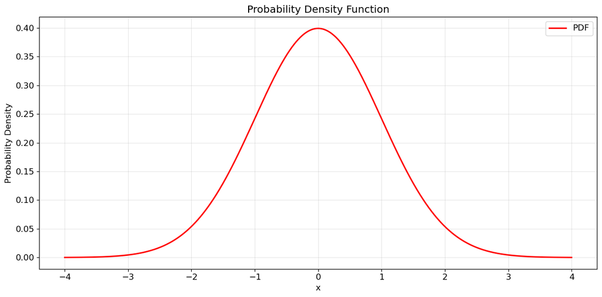

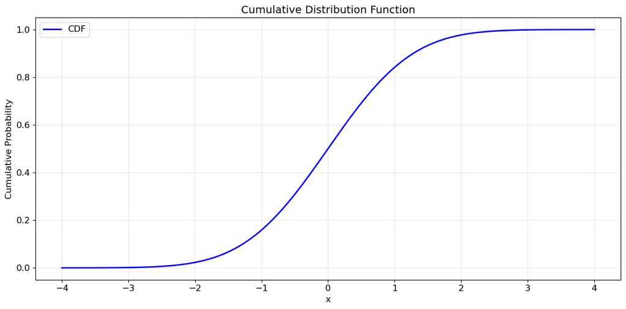

```python
# Create x values for plotting
x = np.linspace(-4, 4, 1000)

# Calculate PDF using .pdf() method
pdf = gaussian.pdf(x)

# Calculate CDF using .cdf() method
cdf = gaussian.cdf(x)

# Plot the PDF
plt.figure(figsize=(12, 6))
plt.plot(x, pdf, 'r-', linewidth=2, label='PDF')
plt.xlabel('x')
plt.ylabel('Probability Density')
plt.title('Probability Density Function')
plt.legend()
plt.grid(True, alpha=0.3)
plt.tight_layout()
plt.show()

# Plot the CDF
plt.figure(figsize=(12, 6))
plt.plot(x, cdf, 'b-', linewidth=2, label='CDF')
plt.xlabel('x')
plt.ylabel('Cumulative Probability')
plt.title('Cumulative Distribution Function')
plt.legend()
plt.grid(True, alpha=0.3)
plt.tight_layout()
plt.show()
```

The PDF shows probability density - it peaks at the mean and falls off in the tails. The CDF shows accumulated probability - it starts near 0, rises steeply through the center (where the PDF is high, so probability accumulates quickly), and approaches 1 in the upper tail. Where the PDF is high, the CDF rises steeply. Where the PDF is low (in the tails), the CDF is nearly flat because little probability accumulates there.

### Finding Percentiles

The CDF tells us "what fraction falls below this value?" But sometimes we want to ask the reverse question: "what value has 90% of the data below it?" This is asking for a **percentile**. The `.ppf()` method (percent point function, the inverse of CDF) finds percentiles.

The `.ppf()` method takes a probability (between 0 and 1) and returns the corresponding value. Let's find the median (50th percentile):

```python
# Use the .ppf() method to find the value at 50th percentile (median)
# ppf takes a probability (0.5 = 50%) and returns the corresponding x value
median = gaussian.ppf(0.5)

print(f"50th percentile (median): {median:.4f}")
```

```
50th percentile (median): 0.0000
```

For a Gaussian, the median equals the mean (because the distribution is symmetric). The value 0.5 means we want the value below which 50% of the data falls. Let's find several key percentiles:

```python
# Define percentiles corresponding to ±1σ and ±2σ for a Gaussian
percentiles = [0.02275, 0.15866, 0.50, 0.84134, 0.97725]

# Use .ppf() to find the x values at these percentiles
values = gaussian.ppf(percentiles)

# Print each percentile and its corresponding value
for p, v in zip(percentiles, values):
    print(f"{p*100:5.2f}th percentile: x = {v:6.3f}")
```

```
 2.27th percentile: x = -2.000
15.87th percentile: x = -1.000
50.00th percentile: x =  0.000
84.13th percentile: x =  1.000
97.72th percentile: x =  2.000
```

These percentiles have special meaning for Gaussian distributions. Recall that we defined our distribution with μ = 0 and σ = 1. The 15.87th and 84.13th percentiles bracket the central 68% of the distribution - these correspond to μ−σ and μ+σ (one standard deviation below and above the mean). The 2.28th and 97.73th percentiles bracket the central 95% - these correspond to μ−2σ and μ+2σ (two standard deviations below and above the mean). This connects directly to the descriptive statistics we learned earlier.

### Understanding Measurement Uncertainty

For Gaussian-distributed measurements, about 68% of values fall within ±1σ of the mean, about 95% fall within ±2σ, and about 99.7% fall within ±3σ. This is fundamental for interpreting uncertainties in astronomy. When you see a measurement reported as 10.5 ± 0.1, that ±0.1 typically represents 1σ (one standard deviation), meaning there's roughly a 68% chance the true value lies in the range 10.4 to 10.6.

**Intuitive Understanding:** Think of the CDF as a way to measure "how much probability have we accumulated up to this point?" When we want to know the probability of falling within a range, we're asking "how much probability is between these two points?" This is like measuring the distance between two marks on a ruler - we take the position of the right mark (the upper CDF value) and subtract the position of the left mark (the lower CDF value). The difference tells us how much probability lies in between.

For example, to find the probability within ±1σ, we calculate CDF(+1σ) - CDF(-1σ). The CDF(+1σ) tells us "what fraction of values fall below +1σ" (about 84%), and CDF(-1σ) tells us "what fraction fall below -1σ" (about 16%). The difference, 84% - 16% = 68%, is the fraction that falls *between* -1σ and +1σ.

Let's verify this rule with our distribution:

```python
# Calculate probability within ±1σ: P(-1 ≤ X ≤ 1) = CDF(1) - CDF(-1)
prob_1sigma = gaussian.cdf(1) - gaussian.cdf(-1)

# Calculate probability within ±2σ: P(-2 ≤ X ≤ 2) = CDF(2) - CDF(-2)
prob_2sigma = gaussian.cdf(2) - gaussian.cdf(-2)

# Calculate probability within ±3σ: P(-3 ≤ X ≤ 3) = CDF(3) - CDF(-3)
prob_3sigma = gaussian.cdf(3) - gaussian.cdf(-3)

# Calculate probability within ±4σ: P(-4 ≤ X ≤ 4) = CDF(4) - CDF(-4)
prob_4sigma = gaussian.cdf(4) - gaussian.cdf(-4)

# Calculate probability within ±5σ: P(-5 ≤ X ≤ 5) = CDF(5) - CDF(-5)
prob_5sigma = gaussian.cdf(5) - gaussian.cdf(-5)

print(f"Probability within ±1σ: {prob_1sigma:.4f} (about 68%)")
print(f"Probability within ±2σ: {prob_2sigma:.4f} (about 95%)")
print(f"Probability within ±3σ: {prob_3sigma:.4f} (about 99.7%)")
print(f"Probability within ±4σ: {prob_4sigma:.6f} (about 99.9937%)")
print(f"Probability within ±5σ: {prob_5sigma:.7f} (about 99.99994%)")
```

```
Probability within ±1σ: 0.6827 (about 68%)
Probability within ±2σ: 0.9545 (about 95%)
Probability within ±3σ: 0.9973 (about 99.7%)
Probability within ±4σ: 0.999937 (about 99.9937%)
Probability within ±5σ: 0.9999994 (about 99.99994%)
```

The calculations confirm the rule. This is why astronomers often talk about "3-sigma detections" or "5-sigma confidence." When you detect something at 3σ significance, it means the observation deviates from the null hypothesis by more than 3 standard deviations - something that would happen only 0.3% of the time by random chance if the null hypothesis were true. A 5σ detection corresponds to a probability of only 0.00006% occurring by chance - this is the standard for claiming a discovery in particle physics and is increasingly used in astronomy for major claims.

Let's visualize these regions:

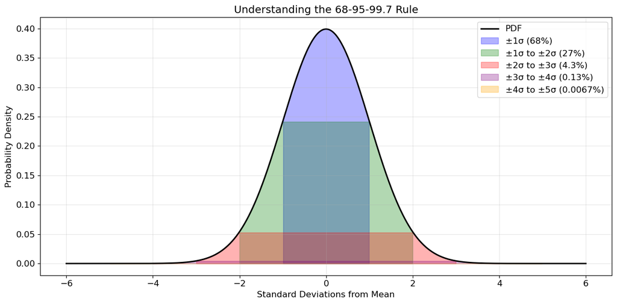

```python
# Create x values for plotting
x = np.linspace(-6, 6, 1000)

# Calculate PDF
pdf = gaussian.pdf(x)

# Create the plot
plt.figure(figsize=(12, 6))
plt.plot(x, pdf, 'k-', linewidth=2, label='PDF')

# Shade the ±1σ region (68% of probability)
mask_1sigma = np.abs(x) <= 1
plt.fill_between(x[mask_1sigma], pdf[mask_1sigma], alpha=0.3, color='blue',
                 label='±1σ (68%)')

# Shade the ±1σ to ±2σ region (27% of probability)
mask_2sigma = (np.abs(x) > 1) & (np.abs(x) <= 2)
plt.fill_between(x[mask_2sigma], pdf[mask_2sigma], alpha=0.3, color='green',
                 label='±1σ to ±2σ (27%)')

# Shade the ±2σ to ±3σ region (4.3% of probability)
mask_3sigma = (np.abs(x) > 2) & (np.abs(x) <= 3)
plt.fill_between(x[mask_3sigma], pdf[mask_3sigma], alpha=0.3, color='red',
                 label='±2σ to ±3σ (4.3%)')

# Shade the ±3σ to ±4σ region (0.13% of probability)
mask_4sigma = (np.abs(x) > 3) & (np.abs(x) <= 4)
plt.fill_between(x[mask_4sigma], pdf[mask_4sigma], alpha=0.3, color='purple',
                 label='±3σ to ±4σ (0.13%)')

# Shade the ±4σ to ±5σ region (0.0067% of probability)
mask_5sigma = (np.abs(x) > 4) & (np.abs(x) <= 5)
plt.fill_between(x[mask_5sigma], pdf[mask_5sigma], alpha=0.3, color='orange',
                 label='±4σ to ±5σ (0.0067%)')


plt.xlabel('Standard Deviations from Mean')
plt.ylabel('Probability Density')
plt.title('Understanding the 68-95-99.7 Rule')
plt.legend()
plt.grid(True, alpha=0.3)
plt.tight_layout()
plt.show()
```

## Other Important Distributions

The Gaussian distribution is the most common in astronomy, but scipy.stats provides many other distributions, all with the same interface. Once you understand how to work with one distribution, you can work with any distribution by simply creating a different distribution object.

### The Exponential Distribution

The **exponential distribution** describes the time between independent random events that occur at a steady average rate. In astronomy, exponential distributions appear when modeling waiting times - for example, the time between supernovae explosions in a galaxy, or the time between detecting gamma-ray bursts across the sky.

The exponential distribution has one parameter: `scale`, which equals the mean waiting time. Let's create an exponential distribution with mean 2.0:

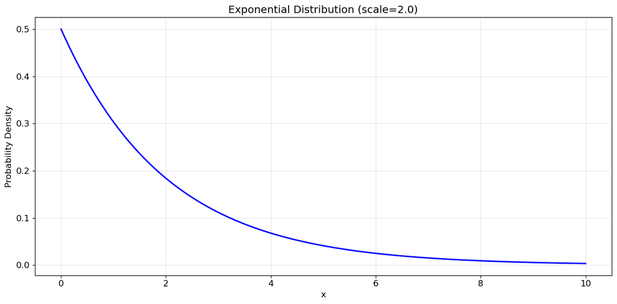

```python
# Create an exponential distribution object with scale=2.0 (mean waiting time)
exponential = stats.expon(scale=2.0)

# Create x values for plotting (exponential is defined for x ≥ 0)
x = np.linspace(0, 10, 1000)

# Calculate PDF using .pdf() method
pdf_exp = exponential.pdf(x)

# Plot the exponential distribution
plt.figure(figsize=(12, 6))
plt.plot(x, pdf_exp, 'b-', linewidth=2)
plt.xlabel('x')
plt.ylabel('Probability Density')
plt.title('Exponential Distribution (scale=2.0)')
plt.grid(True, alpha=0.3)
plt.tight_layout()
plt.show()
```

The exponential PDF starts high at $x=0$ and decreases exponentially. This makes sense for waiting times: short waits are more likely than long waits. The key insight is that this distribution object works exactly like the Gaussian we used earlier - it has `.pdf()`, `.cdf()`, `.ppf()`, `.rvs()` methods that work the same way.

### The Unified Interface

The power of scipy.stats is that all distributions share the same methods. Whether you're working with `stats.norm()`, `stats.uniform()`, `stats.expon()`, `stats.poisson()`, or any other distribution, the interface is identical: `.pdf()` or `.pmf()` computes probability density (or mass for discrete distributions), `.cdf()` computes cumulative probability, `.ppf()` finds percentiles, `.rvs()` generates random samples, and `.mean()` and `.std()` return distribution parameters.

SciPy stats distribution objects also have a `.mean()` method that calculates the theoretical mean of the distribution based on its parameters. This is different from `np.mean()`, which computes the sample mean from data. For example, `stats.norm(loc=10, scale=2).mean()` returns 10.0 (the theoretical mean of that Gaussian distribution), while `np.mean(data)` calculates the average of your actual data points.

Let's demonstrate this with three different distributions:

```python
# Create three different distribution objects
# Gaussian with loc=10 (mean) and scale=2 (std dev)
normal_dist = stats.norm(loc=10, scale=2)

# Uniform from loc=5 to loc+scale=15
uniform_dist = stats.uniform(loc=5, scale=10)

# Exponential with scale=2 (mean)
exponential_dist = stats.expon(scale=2)

# Store distributions in a list for easy iteration
distributions = [
    ("Gaussian", normal_dist),
    ("Uniform", uniform_dist),
    ("Exponential", exponential_dist)
]

# Demonstrate that all distributions have the same interface
for name, dist in distributions:
    # Use .mean() and .std() methods
    mean = dist.mean()
    std = dist.std()
    # Use .ppf() to find the median (50th percentile)
    median = dist.ppf(0.5)
    # Use .rvs() to generate a random sample
    sample = dist.rvs()

    print(f"{name} distribution:")
    print(f"  Mean: {mean:.3f}")
    print(f"  Std: {std:.3f}")
    print(f"  Median: {median:.3f}")
    print(f"  Random sample: {sample:.3f}")
    print()
```

```
Gaussian distribution:
  Mean: 10.000
  Std: 2.000
  Median: 10.000
  Random sample: 8.458

Uniform distribution:
  Mean: 10.000
  Std: 2.887
  Median: 10.000
  Random sample: 7.943

Exponential distribution:
  Mean: 2.000
  Std: 2.000
  Median: 1.386
  Random sample: 2.882
```

And we can also plot the pdf of these distributions:

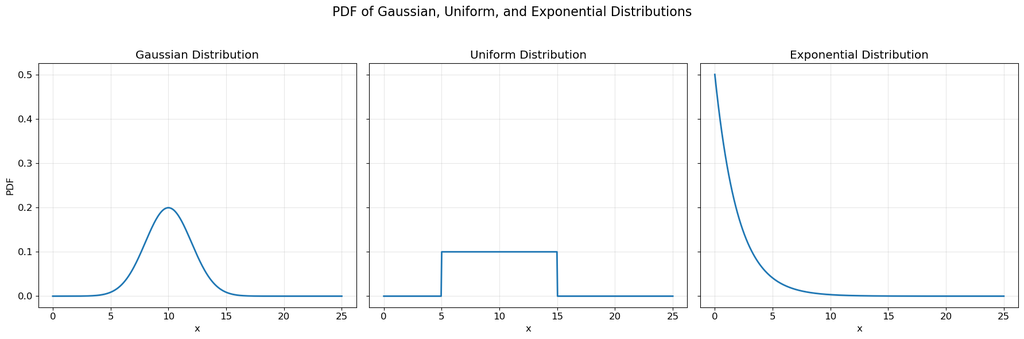

```python
# Create a range of x values suitable to show all three distributions
x = np.linspace(0, 25, 500)

fig, axes = plt.subplots(1, 3, figsize=(18, 6), sharey=True)

for ax, (name, dist) in zip(axes, distributions):
    ax.plot(x, dist.pdf(x), color='C0', lw=2)
    ax.set_title(f"{name} Distribution")
    ax.set_xlabel("x")
    ax.grid(alpha=0.3)
axes[0].set_ylabel("PDF")

fig.suptitle("PDF of Gaussian, Uniform, and Exponential Distributions", fontsize=16)
plt.tight_layout(rect=[0, 0, 1, 0.95])
plt.show()
```

All three distributions respond to the same methods. This unified interface makes `scipy.stats` extremely powerful - once you've mastered these concepts with Gaussian distributions, you can immediately apply them to any distribution. When you encounter a new type of data, you can explore different distributions by simply creating different distribution objects and comparing how well they match your data.

## Combining Measurements

One of the most common tasks in astronomy is combining multiple measurements of the same quantity. You observe a star on ten different nights and want to determine its best magnitude estimate. How do you properly combine these measurements? The answer depends on whether all measurements have equal reliability.

### Simple Average for Equal Uncertainties

If all measurements have equal uncertainty, the simple average is optimal:

$$\bar{x} = \frac{1}{n}\sum_{i=1}^n x_i$$

But what about the uncertainty in this average? Statistics gives us an important answer: if each of your `n` independent measurements has the same uncertainty `σ`, the uncertainty in their average decreases by a factor of $\sqrt{n}$:

$$\sigma_{\bar{x}} = \frac{\sigma}{\sqrt{n}}$$

This is a foundational result in statistics. For example, if you double your observing time (collect twice as many independent measurements), your uncertainty drops by a factor of $\sqrt{2} \approx 1.4$. To cut the uncertainty in half, you need four times as many measurements; to reduce it by a factor of ten, you need 100 times as many. This square-root relationship explains why dramatically increasing precision requires so much more effort and data.

Why does this formula work? The intuition is that combining independent, equally reliable measurements helps to average out random errors. The mathematical proof for this result relies on how variances add up and will be covered more rigorously in a dedicated statistics course, where you'll see exactly why the uncertainty falls with $1/\sqrt{n}$. For now, it's important to know this rule-of-thumb for uncertainty reduction—and to appreciate both its power and its practical limitations.

```python
# Set random seed for reproducibility
np.random.seed(42)

# Define the true magnitude and measurement parameters
true_mag = 12.0   # The star's actual magnitude
sigma = 0.08      # Uncertainty in each individual measurement (all equal)
n_measurements = 10  # Number of observations

# Generate measurements by adding Gaussian noise to the true value
# Each measurement = true_mag + random_error, where error ~ N(0, σ)
measurements = true_mag + np.random.normal(loc=0, scale=sigma, size=n_measurements)

# Display the individual measurements
print(f"True magnitude: {true_mag:.4f}")
print(f"\nIndividual measurements (each with σ = {sigma:.3f}):")
for i, m in enumerate(measurements, 1):
    print(f"  Measurement {i}: {m:.4f}")
```

```
True magnitude: 12.0000

Individual measurements (each with σ = 0.080):
  Measurement 1: 12.0397
  Measurement 2: 11.9889
  Measurement 3: 12.0518
  Measurement 4: 12.1218
  Measurement 5: 11.9813
  Measurement 6: 11.9813
  Measurement 7: 12.1263
  Measurement 8: 12.0614
  Measurement 9: 11.9624
  Measurement 10: 12.0434
```

Now let's calculate the simple average using `np.mean()`, and compute the uncertainty in this average using the formula $\sigma_{\bar{x}} = \sigma / \sqrt{n}$:

```python
# Calculate the simple average of all measurements
simple_mean = np.mean(measurements)

# Calculate the uncertainty in the mean using σ_mean = σ / √n
uncertainty_mean = sigma / np.sqrt(n_measurements)

# Display the results
print(f"Simple average: {simple_mean:.4f} ± {uncertainty_mean:.4f}")
print(f"\nUncertainty reduction factor: √{n_measurements} = {np.sqrt(n_measurements):.2f}")
print(f"Original uncertainty (σ): {sigma:.4f}")
print(f"New uncertainty (σ/√n): {uncertainty_mean:.4f}")
```

```
Simple average: 12.0358 ± 0.0253

Uncertainty reduction factor: √10 = 3.16
Original uncertainty (σ): 0.0800
New uncertainty (σ/√n): 0.0253
```

**Important note on reporting uncertainties:** When quoting measurements with errors in the form xx ± yy, both the value and the uncertainty should be rounded to the same decimal place to be meaningful. For example, writing "12.04 ± 0.03" is appropriate, but writing "12.0358412 ± 0.0253" provides false precision since the uncertainty itself is uncertain. A common convention is to round the uncertainty to 1-2 significant figures, then round the measurement value to match the last decimal place of the uncertainty. In our example above, both values are shown to 4 decimal places (12.0358 ± 0.0253), which maintains proper alignment and readability.

### Weighted Average for Different Uncertainties

When measurements have different uncertainties, treating them equally is suboptimal. You want to trust precise measurements more than imprecise ones. The optimal way is through **weighted averaging**, where each measurement's influence is proportional to its precision.

For measurements $m_i$ with uncertainties $\sigma_i$, we assign weights inversely proportional to the squared uncertainties:

$$w_i = \frac{1}{\sigma_i^2}$$

Why inverse square? Because precision scales with inverse variance. A measurement with `σ = 0.1` isn't twice as good as one with `σ = 0.2` - it's four times as good. Think about it: if you had four measurements each with `σ = 0.2`, their combined uncertainty would be $0.2/\sqrt{4} = 0.1$, matching the single precise measurement. So one measurement with `σ = 0.1` contains as much information as four measurements with `σ = 0.2`. Precision scales with $1/\sigma^2$, not $1/\sigma$.

The weighted average is:

$$\bar{m}_w = \frac{\sum_i w_i m_i}{\sum_i w_i}$$

This is a regular average, but each measurement appears in proportion to its weight. Precise measurements (large $w_i$) contribute more, imprecise measurements (small $w_i$) contribute less. The uncertainty in the weighted average is:

$$\sigma_{\bar{m}_w} = \frac{1}{\sqrt{\sum_i w_i}}$$

This formula shows that combining measurements reduces uncertainty. The more measurements you have, and the more precise they are (larger weights), the smaller $\sigma_{\bar{m}_w}$ becomes. Notice the structure: each measurement contributes $1/\sigma_i^2$ to the total weight, and the final uncertainty goes as one over the square root of the total weight. This weighted average is optimal - it gives you the smallest possible uncertainty when combining independent Gaussian measurements. The mathematical proof of why this weighting scheme is optimal can be derived rigorously in a future statistics course, where you'll see how it emerges from minimizing the variance of the combined estimate.

Let's apply this to a realistic example. We'll simulate ten magnitude measurements of a star, each with different uncertainties:

```python
# Set random seed for reproducibility
np.random.seed(42)

# Define the true magnitude
true_mag = 12.0

# Define uncertainties for each measurement (now they're different!)
uncertainties_array = np.array([0.05, 0.08, 0.10, 0.07, 0.12, 0.06, 0.09, 0.11, 0.08, 0.10])

# Generate measurements by adding Gaussian noise scaled to each uncertainty
# For each measurement i: measurement_i = true_mag + N(0, σ_i)
measurements_array = true_mag + np.random.normal(loc=0, scale=uncertainties_array)

# Display the measurements with their individual uncertainties
print(f"True magnitude: {true_mag:.4f}\n")
print("Individual measurements with varying uncertainties:")
for i, (m, sig) in enumerate(zip(measurements_array, uncertainties_array), 1):
    print(f"  Measurement {i}: {m:.4f} ± {sig:.3f}")
```

```
True magnitude: 12.0000

Individual measurements with varying uncertainties:
  Measurement 1: 12.0248 ± 0.050
  Measurement 2: 11.9889 ± 0.080
  Measurement 3: 12.0648 ± 0.100
  Measurement 4: 12.1066 ± 0.070
  Measurement 5: 11.9719 ± 0.120
  Measurement 6: 11.9860 ± 0.060
  Measurement 7: 12.1421 ± 0.090
  Measurement 8: 12.0844 ± 0.110
  Measurement 9: 11.9624 ± 0.080
  Measurement 10: 12.0543 ± 0.100
```

Now let's calculate the weights $w_i = 1/\sigma_i^2$ for each measurement, then compute the weighted average and its uncertainty:

```python
# Calculate weights: w_i = 1 / σ_i²
weights = 1 / uncertainties_array**2

# Calculate weighted average: Σ(w_i * m_i) / Σ(w_i)
weighted_mean = np.sum(weights * measurements_array) / np.sum(weights)

# Calculate uncertainty in weighted average: 1 / √(Σ w_i)
weighted_uncertainty = 1 / np.sqrt(np.sum(weights))

# Also calculate simple average for comparison
simple_mean = np.mean(measurements_array)
simple_uncertainty = np.sqrt(np.sum(uncertainties_array**2)) / len(uncertainties_array)

# Display results
print(f"Simple average: {simple_mean:.4f} ± {simple_uncertainty:.4f}")
print(f"Weighted average: {weighted_mean:.4f} ± {weighted_uncertainty:.4f}")
print(f"\nTrue magnitude: {true_mag:.4f}")
print(f"Weighted average is closer to truth and has smaller uncertainty!")
```

```
Simple average: 12.0386 ± 0.0280
Weighted average: 12.0327 ± 0.0245

True magnitude: 12.0000
Weighted average is closer to truth and has smaller uncertainty!
```

The weighted average properly accounts for the varying reliability of measurements. The most precise measurements (smallest σ, largest weight) dominate the result, while poor measurements contribute little. This gives both a better estimate (closer to the true value on average) and smaller uncertainty than the simple average. This technique is essential whenever you're combining measurements with different quality - which is almost always the case in real astronomy.

## Identifying and Handling Outliers

Real astronomical data often contains outliers - measurements that deviate dramatically from the expected pattern. Outliers arise from many sources: cosmic rays (high-energy particles from space) hitting your detector during exposure, satellites or airplanes passing through your field of view, tracking errors where the telescope doesn't follow the star perfectly and the star drifts out of your measurement region, clouds passing overhead during your observation, instrumental problems like voltage spikes in the electronics, mistakes in data processing software, or nearby stars accidentally included in your measurement. A single bad measurement can ruin your analysis if not identified and handled properly.

The **3σ rule** provides a statistical criterion for identifying outliers. For Gaussian-distributed data, values beyond μ ± 3σ occur only 0.3% of the time - that's roughly once in 300 measurements. If you observe such a value, you face two interpretations: either it's a genuine 1-in-300 statistical fluctuation, or it's not from the Gaussian distribution you assumed. In practice, the second explanation is usually correct - it's an outlier from some non-Gaussian process like a cosmic ray hit or instrumental error.

Let's create a dataset with some outliers to demonstrate the 3σ rule. We'll generate clean data from a Gaussian, then add some extreme values:

```python
# Set random seed for reproducibility
np.random.seed(42)

# Generate clean data from a Gaussian distribution: loc=10, scale=1
clean_data = np.random.normal(loc=10, scale=1, size=50)

# Add some extreme outliers (could be from cosmic rays, bad observations, etc.)
outliers = np.array([15, 16, 4, 3])

# Combine clean data and outliers
data_with_outliers = np.concatenate([clean_data, outliers])

print(f"Created dataset with {len(clean_data)} clean points and {len(outliers)} outliers")
print(f"Total: {len(data_with_outliers)} data points")
```

```
Created dataset with 50 clean points and 4 outliers
Total: 54 data points
```

Now let's calculate the mean and standard deviation of this data, then define the 3σ bounds (mean ± 3σ):

```python
# Calculate mean using np.mean()
mean_with_outliers = np.mean(data_with_outliers)

# Calculate standard deviation using np.std()
std_with_outliers = np.std(data_with_outliers)

# Define the 3σ bounds
lower_bound = mean_with_outliers - 3 * std_with_outliers
upper_bound = mean_with_outliers + 3 * std_with_outliers

print(f"Mean: {mean_with_outliers:.3f}")
print(f"Standard deviation: {std_with_outliers:.3f}")
print(f"\n3σ bounds:")
print(f"  Lower bound (μ - 3σ): {lower_bound:.3f}")
print(f"  Upper bound (μ + 3σ): {upper_bound:.3f}")
```

```
Mean: 9.754
Standard deviation: 1.866

3σ bounds:
  Lower bound (μ - 3σ): 4.157
  Upper bound (μ + 3σ): 15.352
```

Now let's visualize the data, highlighting the outliers and showing the 3σ region:

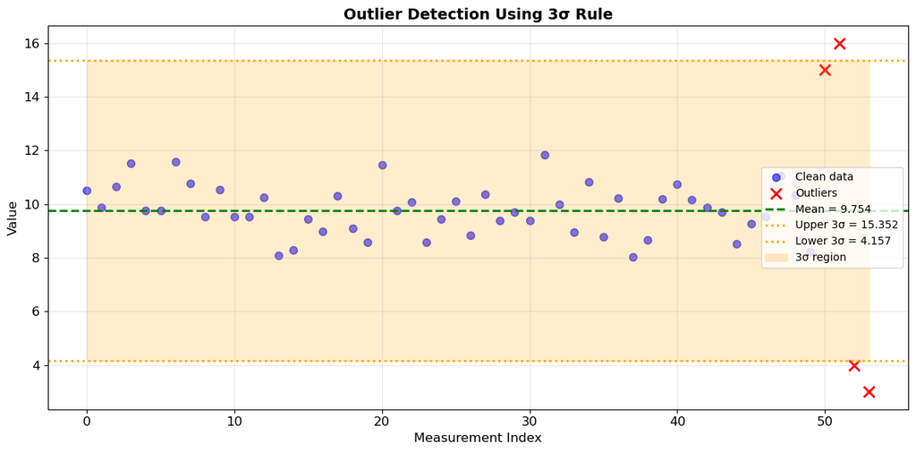

```python
# Create the figure
fig, ax = plt.subplots(figsize=(12, 6))

# Plot clean data points (blue circles)
ax.scatter(np.arange(len(clean_data)), clean_data, c='blue', alpha=0.6,
           label='Clean data', s=50)

# Plot outliers (red X marks)
ax.scatter(np.arange(len(clean_data), len(data_with_outliers)), outliers,
           c='red', marker='x', s=100, label='Outliers', linewidths=2)

# Draw horizontal lines for mean and 3σ bounds
ax.axhline(mean_with_outliers, color='green', linestyle='--', linewidth=2,
           label=f'Mean = {mean_with_outliers:.3f}')
ax.axhline(upper_bound, color='orange', linestyle=':', linewidth=2,
           label=f'Upper 3σ = {upper_bound:.3f}')
ax.axhline(lower_bound, color='orange', linestyle=':', linewidth=2,
           label=f'Lower 3σ = {lower_bound:.3f}')

# Shade the 3σ region
ax.fill_between(np.arange(len(data_with_outliers)), lower_bound, upper_bound,
                alpha=0.2, color='orange', label='3σ region')

ax.set_xlabel('Measurement Index', fontsize=12)
ax.set_ylabel('Value', fontsize=12)
ax.set_title('Outlier Detection Using 3σ Rule', fontsize=14, fontweight='bold')
ax.legend(loc='best', fontsize=10)
ax.grid(True, alpha=0.3)
plt.tight_layout()
plt.show()
```

### Sigma Clipping

Sigma clipping works iteratively: first, compute the mean and standard deviation; second, identify and remove points beyond 3σ; third, recompute mean and standard deviation on the cleaned data; fourth, identify and remove points beyond the new 3σ bounds; fifth, repeat until no more points are removed. Each iteration removes outliers, allowing the statistics to converge to values representative of the clean data rather than being contaminated by the outliers.

Let's implement sigma clipping. We'll use `sigma=3` (for 3σ clipping) and `max_iterations=10` to prevent infinite loops:

```python
# Set parameters for sigma clipping
sigma = 3  # Number of standard deviations for clipping threshold
max_iterations = 10  # Maximum iterations to prevent infinite loops

# Start with all data
clipped = data_with_outliers.copy()

# Iterate until convergence or max iterations reached
for iteration in range(max_iterations):
    # Step 1: Calculate mean and std of current data using np.mean() and np.std()
    mean = np.mean(clipped)
    std = np.std(clipped)

    # Step 2: Define outlier bounds as mean ± sigma*std
    lower = mean - sigma * std
    upper = mean + sigma * std

    # Step 3: Create a mask to keep only points within bounds
    mask = (clipped >= lower) & (clipped <= upper)
    new_clipped = clipped[mask]

    # Step 4: Check for convergence - stop if no points were removed
    if len(new_clipped) == len(clipped):
        print(f"Converged after {iteration} iterations")
        break

    # Step 5: Update clipped data for next iteration
    clipped = new_clipped

# Display results
print(f"\nOriginal data: {len(data_with_outliers)} points")
print(f"After clipping: {len(clipped)} points")
print(f"Removed: {len(data_with_outliers) - len(clipped)} outliers")
print(f"\nMean before clipping: {np.mean(data_with_outliers):.3f}")
print(f"Mean after clipping: {np.mean(clipped):.3f}")
print(f"True value: 10.000")
```

```
Converged after 2 iterations

Original data: 54 points
After clipping: 50 points
Removed: 4 outliers

Mean before clipping: 9.754
Mean after clipping: 9.775
True value: 10.000
```

## Fitting Distributions to Data

So far, we've been working with distributions where we specified the parameters ourselves. But in real astronomy, you often need to determine which distribution best describes your data and estimate its parameters from the data itself. This is called **distribution fitting**.

The question is: given a dataset, what distribution does it come from, and what are the parameters? For example, if you measure stellar velocities in a galaxy cluster, you might hypothesize they follow a Gaussian distribution. But what are the mean velocity and velocity dispersion? Fitting determines these parameters from your data.

### Fitting a Gaussian Distribution

For a Gaussian, the simplest approach is using the sample mean and standard deviation. Let's generate some synthetic data from a Gaussian distribution and fit it. We'll use a true mean of `15.0` and a true standard deviation of `2.5`:

```python
# Set random seed for reproducibility
np.random.seed(42)

# Define true parameters
true_mean = 15.0
true_std = 2.5

# Generate 200 random samples from a Gaussian distribution with these parameters
data = np.random.normal(loc=true_mean, scale=true_std, size=200)

print(f"Generated {len(data)} data points")
print(f"True parameters: μ = {true_mean}, σ = {true_std}")
```

```
Generated 200 data points
True parameters: μ = 15.0, σ = 2.5
```

Now let's estimate the distribution parameters from the data using `np.mean()` and `np.std()`, then create a fitted distribution object:

```python
# Estimate parameters from the data
estimated_mean = np.mean(data)
estimated_std = np.std(data)

# Create a fitted Gaussian distribution object using the estimated parameters
fitted_gaussian = stats.norm(loc=estimated_mean, scale=estimated_std)

print(f"Estimated parameters:")
print(f"  μ̂ (estimated mean) = {estimated_mean:.4f}")
print(f"  σ̂ (estimated std)  = {estimated_std:.4f}")
print(f"\nTrue parameters:")
print(f"  μ (true mean) = {true_mean:.4f}")
print(f"  σ (true std)  = {true_std:.4f}")
print(f"\nThe estimates are close to the true values!")
```

```
Estimated parameters:
  μ̂ (estimated mean) = 14.8981
  σ̂ (estimated std)  = 2.3217

True parameters:
  μ (true mean) = 15.0000
  σ (true std)  = 2.5000

The estimates are close to the true values!
```

The estimated parameters are close to the true values. With more data points, the estimates would be even more accurate. Let's visualize how well this fitted distribution describes our data:

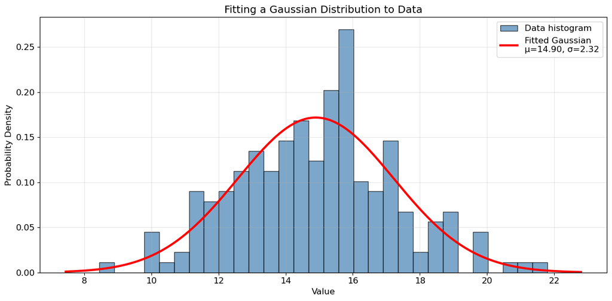

```python
# Create x values for plotting the fitted PDF
x = np.linspace(data.min() - 1, data.max() + 1, 1000)

# Calculate the fitted PDF using the .pdf() method
fitted_pdf = fitted_gaussian.pdf(x)

# Create the plot
plt.figure(figsize=(12, 6))

# Plot histogram of data (density=True normalizes to probability density)
plt.hist(data, bins=30, density=True, alpha=0.7, edgecolor='black',
         color='steelblue', label='Data histogram')

# Plot the fitted PDF curve
plt.plot(x, fitted_pdf, 'r-', linewidth=3,
         label=f'Fitted Gaussian\nμ={estimated_mean:.2f}, σ={estimated_std:.2f}')

plt.xlabel('Value')
plt.ylabel('Probability Density')
plt.title('Fitting a Gaussian Distribution to Data')
plt.legend()
plt.grid(True, alpha=0.3)
plt.tight_layout()
plt.show()
```

The fitted distribution (red curve) matches the data histogram well. This visual check is important - always plot your fitted distribution against the data to verify the fit makes sense.

### Maximum Likelihood Estimation

For more general distributions, `scipy.stats` provides the `.fit()` method that automatically finds the best parameters. The method uses an approach called **maximum likelihood estimation** (MLE). The intuition is simple: imagine you have your data, and you're trying to guess which parameters produced it. For example, if your data looks like `[2.1, 1.8, 2.3, 1.9, 2.0]`, you might guess the mean is around 2. Maximum likelihood formalizes this intuition mathematically - it finds the parameter values that make your observed data most probable. It answers: "If I had to bet on which parameters generated this data, which values give me the best odds of being right?"

Maximum likelihood estimation is a topic you'll learn properly in a statistics course, but for now, just know that `.fit()` is smart and finds good parameter values automatically. You simply pass your data to `stats.norm.fit()`, and it returns the best-fit parameters:

```python
# Use stats.norm.fit() to automatically find the best parameters
# The .fit() method returns a tuple: (loc, scale) for Gaussian
fitted_params = stats.norm.fit(data)

# Extract the fitted parameters from the tuple
fitted_mean = fitted_params[0]  # loc parameter (mean)
fitted_std = fitted_params[1]   # scale parameter (std dev)

# Display the fitted parameters
print(f"Using stats.norm.fit():")
print(f"  Fitted mean (loc): {fitted_mean:.4f}")
print(f"  Fitted std (scale): {fitted_std:.4f}")
print(f"\nThese match our manual calculations using np.mean() and np.std()!")
```

```
Using stats.norm.fit():
  Fitted mean (loc): 14.8981
  Fitted std (scale): 2.3217

These match our manual calculations using np.mean() and np.std()!
```

For Gaussians, this method gives essentially the same results as using the sample mean and standard deviation that we computed earlier. But for other distributions where the relationship between data and parameters is more complex, `.fit()` is essential because it figures out the math for you.

Let's see this with an exponential distribution. We'll generate some exponential data and use `stats.expon.fit()` to find the best parameters. First, generate the data:

```python
# Set random seed for reproducibility
np.random.seed(42)

# Define true parameter for exponential distribution
true_scale = 3.0

# Generate 500 random samples from an exponential distribution
exponential_data = np.random.exponential(scale=true_scale, size=500)

print(f"Generated {len(exponential_data)} exponential data points")
print(f"True scale parameter: {true_scale}")
```

```
Generated 500 exponential data points
True scale parameter: 3.0
```

Now use `stats.expon.fit()` to estimate the parameters. The exponential distribution has two parameters: `loc` (location/shift) and `scale` (mean):

```python
# Fit exponential distribution to the data
# Returns (loc, scale) where loc is the shift and scale is the mean
loc, fitted_scale = stats.expon.fit(exponential_data)

print(f"Fitted parameters:")
print(f"  loc (location): {loc:.4f}")
print(f"  scale (mean): {fitted_scale:.4f}")
print(f"\nTrue scale: {true_scale:.4f}")
print(f"The fitted scale is close to the true value!")
```

```
Fitted parameters:
  loc (location): 0.0152
  scale (mean): 2.9977

True scale: 3.0000
The fitted scale is close to the true value!
```

Now let's visualize how well the fitted exponential distribution matches the data:

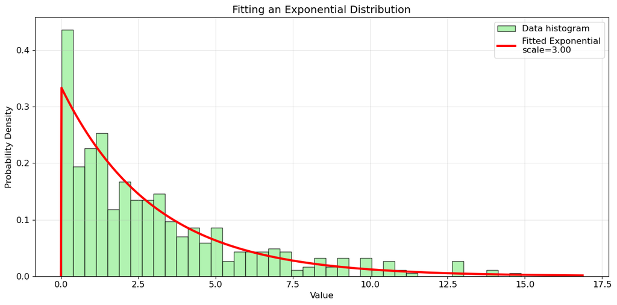

```python
# Create fitted exponential distribution object with estimated parameters
fitted_exponential = stats.expon(loc=loc, scale=fitted_scale)

# Create x values for plotting (exponential is defined for x ≥ 0)
x = np.linspace(0, exponential_data.max() + 2, 1000)

# Calculate the fitted PDF
fitted_pdf = fitted_exponential.pdf(x)

# Create the plot
plt.figure(figsize=(12, 6))

# Plot histogram of data
plt.hist(exponential_data, bins=40, density=True, alpha=0.7, edgecolor='black',
         color='lightgreen', label='Data histogram')

# Plot the fitted exponential PDF
plt.plot(x, fitted_pdf, 'r-', linewidth=3,
         label=f'Fitted Exponential\nscale={fitted_scale:.2f}')

plt.xlabel('Value')
plt.ylabel('Probability Density')
plt.title('Fitting an Exponential Distribution')
plt.legend()
plt.grid(True, alpha=0.3)
plt.tight_layout()
plt.show()
```

The fitted exponential curve matches the data's characteristic shape - high probability near zero, exponentially decreasing for larger values.

### Comparing Different Distributions

In real astronomy, you often don't know which distribution describes your data. You fit multiple distributions and compare them visually. Let's generate data from a gamma distribution and see how different distribution fits compare:

First, generate the data:

```python
# Set random seed for reproducibility
np.random.seed(42)

# Generate 300 data points from a gamma distribution
# a=2.0 is the shape parameter, scale=2.0 is the scale parameter
data = stats.gamma(a=2.0, scale=2.0).rvs(size=300)

print(f"Generated {len(data)} data points from a gamma distribution")
print(f"Data range: [{data.min():.2f}, {data.max():.2f}]")
```

```
Generated 300 data points from a gamma distribution
Data range: [0.31, 14.60]
```

Now fit three different distributions to this data using `.fit()`: Gaussian, exponential, and gamma:

```python
# Fit a Gaussian distribution to the data
gaussian_params = stats.norm.fit(data)
fitted_gaussian = stats.norm(*gaussian_params)

# Fit an exponential distribution to the data
exponential_params = stats.expon.fit(data)
fitted_exponential = stats.expon(*exponential_params)

# Fit a gamma distribution to the data
gamma_params = stats.gamma.fit(data)
fitted_gamma = stats.gamma(*gamma_params)

print("Fitted three different distributions:")
print(f"  1. Gaussian with params: {gaussian_params}")
print(f"  2. Exponential with params: {exponential_params}")
print(f"  3. Gamma with params: {gamma_params}")
```

```
Fitted three different distributions:
  1. Gaussian with params: (np.float64(3.971283293197119), np.float64(2.7075844452481777))
  2. Exponential with params: (0.30702699055796195, 3.6642563026391572)
  3. Gamma with params: (np.float64(1.8803929750997717), np.float64(0.2068982583227274), np.float64(2.0019222585343863))
```

Now let's visualize all three fits together to compare which distribution best describes the data:

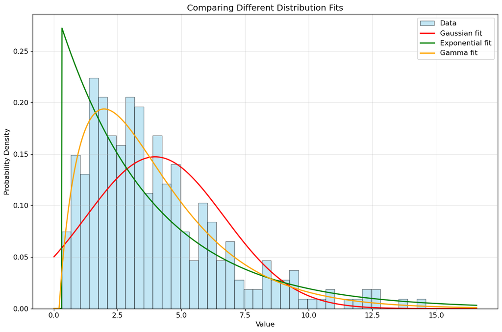

```python
# Create x values for plotting
x = np.linspace(0, data.max() + 2, 1000)

# Create the plot
plt.figure(figsize=(12, 8))

# Plot histogram of data
plt.hist(data, bins=40, density=True, alpha=0.5, edgecolor='black',
         color='skyblue', label='Data')

# Plot Gaussian fit
plt.plot(x, fitted_gaussian.pdf(x), 'r-', linewidth=2, label='Gaussian fit')

# Plot Exponential fit
plt.plot(x, fitted_exponential.pdf(x), 'g-', linewidth=2, label='Exponential fit')

# Plot Gamma fit
plt.plot(x, fitted_gamma.pdf(x), 'orange', linewidth=2, label='Gamma fit')

plt.xlabel('Value')
plt.ylabel('Probability Density')
plt.title('Comparing Different Distribution Fits')
plt.legend()
plt.grid(True, alpha=0.3)
plt.tight_layout()
plt.show()
```

When fitting distributions in real work, keep these points in mind: fitting requires enough data points (aim for at least 50-100), outliers affect fits (consider sigma clipping first), not all distributions are appropriate for all data types (positive quantities need positive-valued distributions), and always visualize your fit.

## Validating Statistical Assumptions

Throughout this lecture, we've assumed measurement errors are Gaussian-distributed. This assumption underlies most of our analysis - from interpreting standard deviations to applying weighted averaging formulas to identifying outliers with the 3σ criterion. But how do we know if this assumption is valid? Testing distributional assumptions is crucial - if your data isn't Gaussian but you assume it is, your conclusions may be wrong.

### What is a Q-Q Plot?

The **Q-Q plot** (quantile-quantile plot) provides a powerful visual test for checking if data follows a particular distribution. Before we dive into how it works, let's understand what quantiles are.

**Understanding quantiles:** Quantiles are values that divide your data into equal-sized groups. You're already familiar with the median, which is the 50th percentile - it divides your data in half. Similarly, the 25th percentile means 25% of your data falls below this value, and the 75th percentile means 75% falls below. These are all examples of quantiles.

**The core idea of Q-Q plots:** Imagine you have 100 measurements and you believe they follow a Gaussian distribution. If this is true, then your data's quantiles should match the theoretical Gaussian quantiles. Your data's 10th percentile should fall where a theoretical Gaussian's 10th percentile would fall. Your median should match the theoretical median. Your 90th percentile should match the theoretical 90th percentile, and so on for all quantiles in between.

**How to read a Q-Q plot:** We create a scatter plot with theoretical quantiles on the x-axis and your actual data's quantiles on the y-axis. If your data truly follows the theoretical distribution, all the points will fall on a straight diagonal line. This makes sense - if the 25th percentile of your data matches the theoretical 25th percentile, that point lies on the diagonal. If all quantiles match, all points lie on the diagonal.

When points deviate from the diagonal line, it tells us something is wrong with our assumption. If the points curve systematically away from the line, we're using the wrong type of distribution entirely. If points in the tails (the extreme values) stray from the line while the middle stays close, it means our data has heavier or lighter tails than the theoretical distribution predicts.

Let's create a Q-Q plot step by step to see this in action. First, we'll generate some data that we know comes from a Gaussian distribution:

```python
# Set random seed for reproducibility
np.random.seed(42)

# Generate 100 data points from a standard Gaussian distribution
gaussian_data = np.random.normal(loc=0, scale=1, size=100)

print(f"Generated {len(gaussian_data)} data points")
print(f"Mean: {np.mean(gaussian_data):.3f}")
print(f"Std: {np.std(gaussian_data):.3f}")
```

```
Generated 100 data points
Mean: -0.104
Std: 0.904
```

Before creating the Q-Q plot, we need to standardize the data (subtract mean, divide by std) to convert it to standard Gaussian form. This standardization is necessary because Q-Q plots compare quantiles between your data and a theoretical distribution. The theoretical standard Gaussian has mean=0 and std=1, so we must transform our data to the same scale. Without standardization, our data might have mean=50 and std=10, making direct quantile comparison meaningless - a value at the 75th percentile in our data wouldn't align with the 75th percentile of the standard Gaussian simply due to scale differences. Standardization ensures we're comparing apples to apples:

```python
# Standardize the data: subtract mean and divide by standard deviation
# This converts it to standard Gaussian form (mean=0, std=1)
standardized = (gaussian_data - np.mean(gaussian_data)) / np.std(gaussian_data)

print(f"Standardized data:")
print(f"  Mean: {np.mean(standardized):.10f} (should be ~0)")
print(f"  Std: {np.std(standardized):.10f} (should be ~1)")
```

```
Standardized data:
  Mean: -0.0000000000 (should be ~0)
  Std: 1.0000000000 (should be ~1)
```

Now use `stats.probplot()` to calculate the theoretical and sample quantiles for the Q-Q plot. The `dist='norm'` parameter specifies we're comparing to a normal (Gaussian) distribution:

```python
# Use stats.probplot() to calculate Q-Q plot data
# Returns: ((theoretical_quantiles, sample_quantiles), (slope, intercept, r_value))
(theoretical_quantiles, sample_quantiles), (slope, intercept, r_value) = \
    stats.probplot(standardized, dist='norm')

print(f"Q-Q plot calculation complete:")
print(f"  Number of quantiles: {len(theoretical_quantiles)}")
```

```
Q-Q plot calculation complete:
  Number of quantiles: 100
```

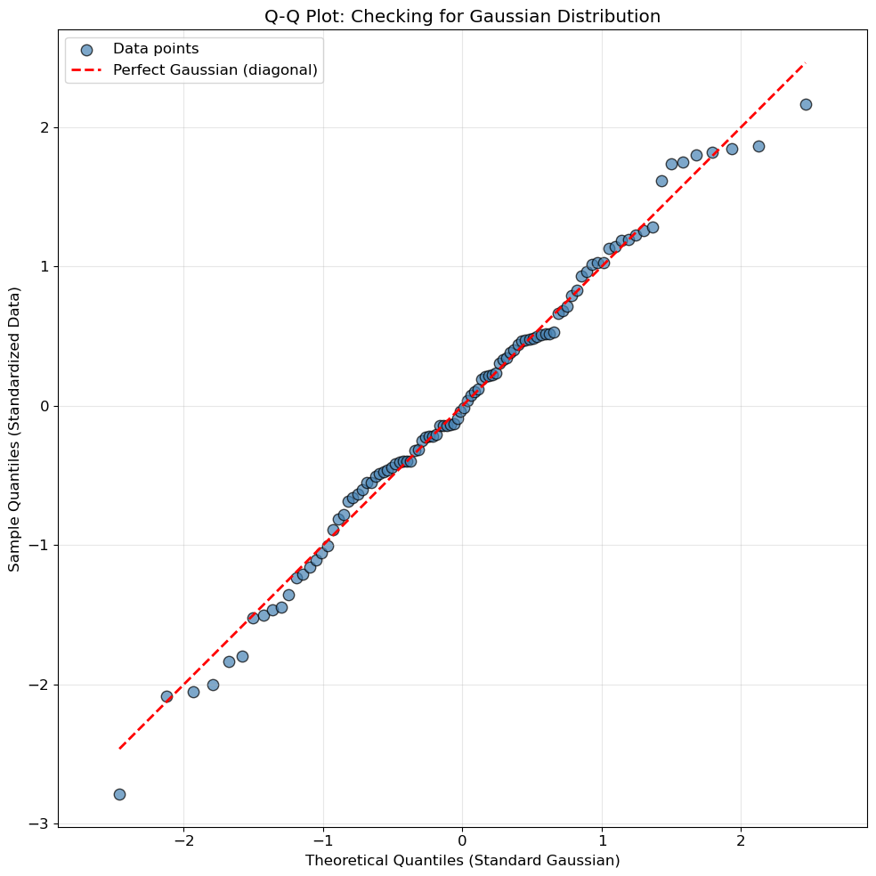

```python
# Create the Q-Q plot
plt.figure(figsize=(10, 10))

# Plot the data points (theoretical quantiles vs sample quantiles)
plt.scatter(theoretical_quantiles, sample_quantiles, s=80, alpha=0.7,
            edgecolor='black', color='steelblue', label='Data points')

# Plot the perfect diagonal line (y=x)
# If data is perfectly Gaussian, all points would fall on this line
plt.plot(theoretical_quantiles, theoretical_quantiles, 'r--', linewidth=2,
         label='Perfect Gaussian (diagonal)')

plt.xlabel('Theoretical Quantiles (Standard Gaussian)')
plt.ylabel('Sample Quantiles (Standardized Data)')
plt.title('Q-Q Plot: Checking for Gaussian Distribution')
plt.legend()
plt.grid(True, alpha=0.3)
plt.axis('equal')  # Equal scaling for both axes
plt.tight_layout()
plt.show()
```

The points fall close to the diagonal line, confirming the data is approximately Gaussian. When points fall on the diagonal, it means the quantiles of your data match the quantiles of a theoretical Gaussian distribution - exactly what we expect for Gaussian data.

Q-Q plots are one of the most important diagnostic tools in statistics. Always create Q-Q plots before trusting analyses that assume a particular distribution. If the Q-Q plot shows clear deviations, you need to either use a different distribution, transform your data (log transformation often helps with skewed data), or use non-parametric methods that don't assume any specific distribution.

## Summary

### Key Concepts

In this lecture, you've learned:

- **The Gaussian Distribution**: Understanding why measurement errors are typically Gaussian due to the Central Limit Theorem - many small independent random effects sum to a Gaussian regardless of individual distributions, explaining why bell curves appear throughout astronomy
- **Working with scipy.stats**: Using distribution objects that provide a unified interface by creating distributions with parameters (such as `stats.norm(loc=μ, scale=σ)`), then using `.pdf()` for probability density, `.cdf()` for cumulative probability, `.ppf()` for percentiles, `.rvs()` for random samples, with the same methods working for all distributions
- **Combining Measurements**: Applying simple averaging for equal uncertainties to reduce uncertainty by $1/\sqrt{n}$, using weighted averaging with weights $w_i = 1/\sigma_i^2$ for varying uncertainties giving uncertainty $1/\sqrt{\sum w_i}$, optimally combining measurements by trusting precise ones more
- **Outlier Detection**: Applying the 3σ rule to identify outliers (values beyond μ ± 3σ occur only 0.3% of the time in Gaussian distributions), using iterative sigma clipping to repeatedly remove outliers and recompute statistics until convergence, preventing outliers from contaminating the statistics used to detect them
- **Fitting Distributions**: Using the `.fit()` method to estimate distribution parameters from data by automatically finding the parameters that best match your data, comparing fits from different distribution families visually, always validating fits with Q-Q plots and CDF comparisons
- **Validating Assumptions**: Using Q-Q plots to check if data follows the assumed distribution where points falling on a diagonal line confirm the assumption, recognizing that systematic deviations indicate you need a different distribution or data transformation

### Practice Suggestions

To solidify these concepts:

1. Analyze real photometric data with measurement uncertainties
2. Simulate observations with noise and outliers, then practice recovering true values
3. Compute weighted averages for multi-epoch observations of variable stars
4. Practice sigma clipping on astronomical images to remove bad pixels (often caused by cosmic rays - high-energy particles from space hitting the detector)
5. Fit multiple distributions to a dataset and use KS tests to compare them
6. Create Q-Q plots to verify measurement errors are Gaussian
7. Use box plots to compare statistics across different stellar populations
8. Experiment with different distributions in scipy.stats (uniform, exponential, Poisson, gamma)

### Looking Ahead

You now have the statistical foundation needed for analyzing astronomical data - understanding probability distributions, combining measurements properly, handling outliers, fitting models to data, and validating assumptions. These skills are essential for Lecture 18, where you'll learn model fitting and optimization using scipy.optimize. In the next few lectures, you'll fit physical models to data (like orbital parameters from radial velocities or atmospheric parameters from stellar spectra), quantify goodness of fit with chi-squared tests, estimate parameter uncertainties, and compare competing models. The statistical concepts from this lecture - weighted averaging, uncertainty propagation, distribution fitting, and assumption validation - form the foundation for extracting physical insights from noisy observations. Every astronomical result you encounter in research papers, from exoplanet masses to cosmological parameters, relies on the statistical techniques you've learned in this lecture.